# USL_Project_TemplateNotebook

## Context

The stock market has consistently proven to be a good place to invest in and save for the future. There are a lot of compelling reasons to invest in stocks. It can help in fighting inflation, create wealth, and also provides some tax benefits. Good steady returns on investments over a long period of time can also grow a lot more than seems possible. Also, thanks to the power of compound interest, the earlier one starts investing, the larger the corpus one can have for retirement. Overall, investing in stocks can help meet life's financial aspirations.

It is important to maintain a diversified portfolio when investing in stocks in order to maximize earnings under any market condition. Having a diversified portfolio tends to yield higher returns and face lower risk by tempering potential losses when the market is down. It is often easy to get lost in a sea of financial metrics to analyze while determining the worth of a stock, and doing the same for a multitude of stocks to identify the right picks for an individual can be a tedious task. By doing a cluster analysis, one can identify stocks that exhibit similar characteristics and ones that exhibit minimum correlation. This will help investors better analyze stocks across different market segments and help protect against risks that could make the portfolio vulnerable to losses.

## Objective :

Trade&Ahead is a financial consultancy firm who provide their customers with personalized investment strategies. They have hired you as a Data Scientist and provided you with data comprising stock price and some financial indicators for a few companies listed under the New York Stock Exchange. They have assigned you the tasks of analyzing the data, grouping the stocks based on the attributes provided, and sharing insights about the characteristics of each group.

## Importing necessary libraries and data

```python
import pandas as pd

import matplotlib.pyplot as plt

import seaborn as sns
import pandas as pd
import numpy as np
```

```python
%%javascript
IPython.OutputArea.prototype._should_scroll = function(lines) {
    return false;
}
```

```python
df = pd.read_csv("stock_data.csv")
```

## Data Overview

- Observations
- Sanity checks

## Data Description

The data provided is of stock prices and some financial indicators like ROE, earnings per share, P/E ratio, etc.

Data Dictionary

Ticker Symbol: An abbreviation used to uniquely identify publicly traded shares of a particular stock on a particular stock market Company: Name of the company \ GICS Sector: The specific economic sector assigned to a company by the Global Industry Classification Standard (GICS) that best defines its business operations \ GICS Sub Industry: The specific sub-industry group assigned to a company by the Global Industry Classification Standard (GICS) that best defines its business operations \ Current Price: Current stock price in dollars \ Price Change: Percentage change in the stock price in 13 weeks \ Volatility: Standard deviation of the stock price over the past 13 weeks \ ROE: A measure of financial performance calculated by dividing net income by shareholders' equity (shareholders' equity is equal to a company's assets minus its debt) \ Cash Ratio: The ratio of a company's total reserves of cash and cash equivalents to its total current liabilities \ Net Cash Flow: The difference between a company's cash inflows and outflows (in dollars) \ Net Income: Revenues minus expenses, interest, and taxes (in dollars) \ Earnings Per Share: Company's net profit divided by the number of common shares it has outstanding (in dollars) \ Estimated Shares Outstanding: Company's stock currently held by all its shareholders \ P/E Ratio: Ratio of the company's current stock price to the earnings per share \ P/B Ratio: Ratio of the company's stock price per share by its book value per share (book value of a company is the net difference between that company's total assets and total liabilities)

```python
df.head()
```

|  | Ticker Symbol | Security | GICS Sector | GICS Sub Industry | Current Price | Price Change | Volatility | ROE | Cash Ratio | Net Cash Flow | Net Income | Earnings Per Share | Estimated Shares Outstanding | P/E Ratio | P/B Ratio |
| --- | --- | --- | --- | --- | --- | --- | --- | --- | --- | --- | --- | --- | --- | --- | --- |
| 0 | AAL | American Airlines Group | Industrials | Airlines | 42.349998 | 9.999995 | 1.687151 | 135 | 51 | -604000000 | 7610000000 | 11.39 | 6.681299e+08 | 3.718174 | -8.784219 |
| 1 | ABBV | AbbVie | Health Care | Pharmaceuticals | 59.240002 | 8.339433 | 2.197887 | 130 | 77 | 51000000 | 5144000000 | 3.15 | 1.633016e+09 | 18.806350 | -8.750068 |
| 2 | ABT | Abbott Laboratories | Health Care | Health Care Equipment | 44.910000 | 11.301121 | 1.273646 | 21 | 67 | 938000000 | 4423000000 | 2.94 | 1.504422e+09 | 15.275510 | -0.394171 |
| 3 | ADBE | Adobe Systems Inc | Information Technology | Application Software | 93.940002 | 13.977195 | 1.357679 | 9 | 180 | -240840000 | 629551000 | 1.26 | 4.996437e+08 | 74.555557 | 4.199651 |
| 4 | ADI | Analog Devices, Inc. | Information Technology | Semiconductors | 55.320000 | -1.827858 | 1.701169 | 14 | 272 | 315120000 | 696878000 | 0.31 | 2.247994e+09 | 178.451613 | 1.059810 |

```python
df.shape
```

```
(340, 15)
```

```python
df.dtypes
```

```
Ticker Symbol                    object
Security                         object
GICS Sector                      object
GICS Sub Industry                object
Current Price                   float64
Price Change                    float64
Volatility                      float64
ROE                               int64
Cash Ratio                        int64
Net Cash Flow                     int64
Net Income                        int64
Earnings Per Share              float64
Estimated Shares Outstanding    float64
P/E Ratio                       float64
P/B Ratio                       float64
dtype: object
```

## Exploratory Data Analysis (EDA)

- EDA is an important part of any project involving data.
- It is important to investigate and understand the data better before building a model with it.
- A few questions have been mentioned below which will help you approach the analysis in the right manner and generate insights from the data.
- A thorough analysis of the data, in addition to the questions mentioned below, should be done.

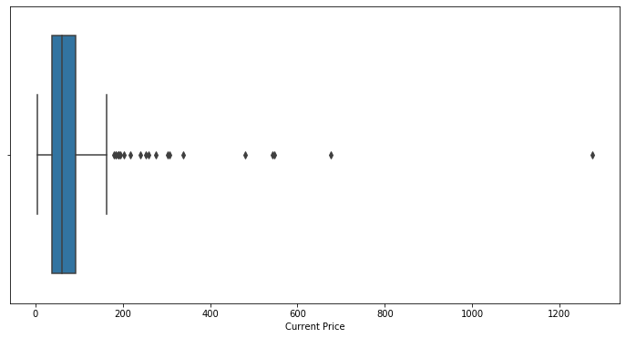

```python
fig, ax = plt.subplots(figsize=(12, 6))

sns.boxplot(df['Current Price'], ax=ax)
```

### Observation :

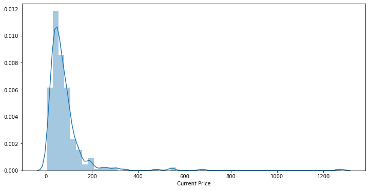

```python
fig, ax = plt.subplots(figsize=(12, 6))
sns.distplot(df['Current Price'], ax=ax)
```

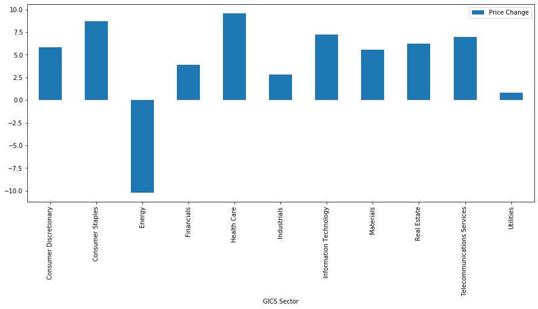

```python
df[["Price Change","GICS Sector"]].groupby(['GICS Sector']).mean().plot(kind='bar', figsize =(15, 6))
```

### Observation :

1. The Energy in overall is negative in average price increase\
2. Health care is the highest avarage in Price Increase

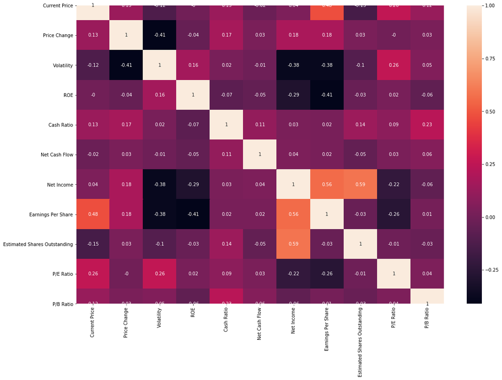

```python
corr = round(df.corr(),2)
fig, ax = plt.subplots(figsize=(18, 12))
sns.heatmap(corr,annot=True)
```

### Observation

1) Net Income is one which is having co-relation greater than 0.5 with "Earnings Per Share" and "Estimated Shares Outstanding"

```python
df1=df.loc[df['P/E Ratio'] < 200]
```

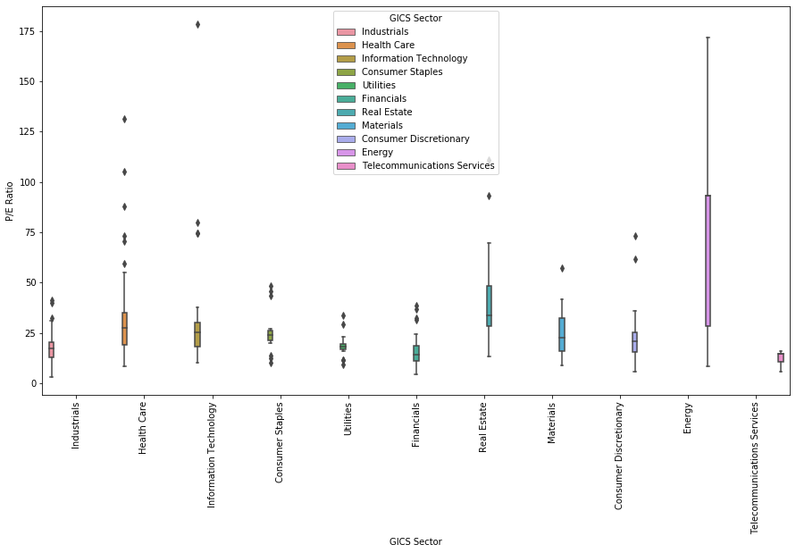

```python
fig, ax = plt.subplots(figsize=(15, 8))
sns.boxplot(x = df1['GICS Sector'],
            y = df1['P/E Ratio'],
            hue = df1['GICS Sector'],ax=ax)
plt.xticks(rotation=90)
```

### Observation:

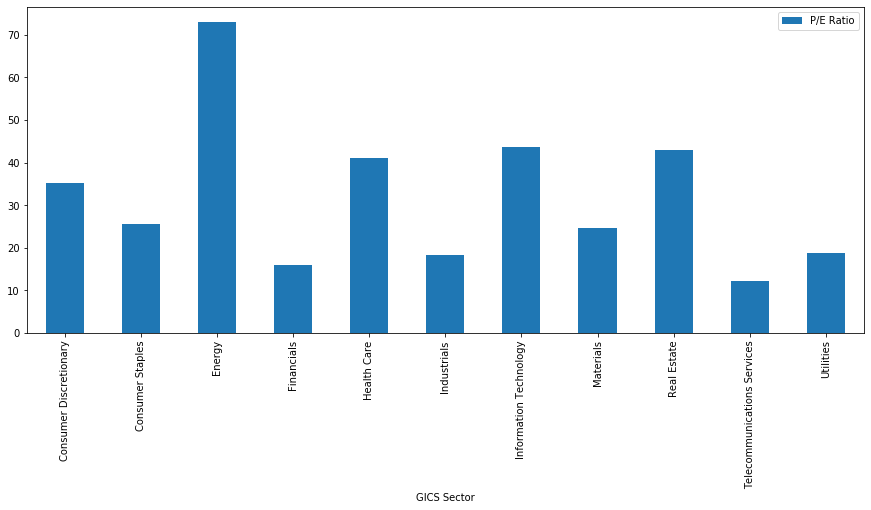

```python
df[["P/E Ratio","GICS Sector"]].groupby(['GICS Sector']).mean().plot(kind='bar', figsize =(15, 6))
```

## Data Preprocessing

- Duplicate value check
- Missing value treatment
- Outlier check
- Feature engineering (if needed)
- Any other preprocessing steps (if needed)

```python
df.isnull().sum()
```

```
Ticker Symbol                   0
Security                        0
GICS Sector                     0
GICS Sub Industry               0
Current Price                   0
Price Change                    0
Volatility                      0
ROE                             0
Cash Ratio                      0
Net Cash Flow                   0
Net Income                      0
Earnings Per Share              0
Estimated Shares Outstanding    0
P/E Ratio                       0
P/B Ratio                       0
dtype: int64
```

```python
df.loc[df['Current Price'] > 1000]
```

|  | Ticker Symbol | Security | GICS Sector | GICS Sub Industry | Current Price | Price Change | Volatility | ROE | Cash Ratio | Net Cash Flow | Net Income | Earnings Per Share | Estimated Shares Outstanding | P/E Ratio | P/B Ratio |
| --- | --- | --- | --- | --- | --- | --- | --- | --- | --- | --- | --- | --- | --- | --- | --- |
| 243 | PCLN | Priceline.com Inc | Consumer Discretionary | Internet & Direct Marketing Retail | 1274.949951 | 3.190527 | 1.26834 | 29 | 184 | -1671386000 | 2551360000 | 50.09 | 50935516.07 | 25.453183 | -1.052429 |

```python
df[["GICS Sector"]].drop_duplicates()
```

|  | GICS Sector |
| --- | --- |
| 0 | Industrials |
| 1 | Health Care |
| 3 | Information Technology |
| 5 | Consumer Staples |
| 7 | Utilities |
| 9 | Financials |
| 11 | Real Estate |
| 15 | Materials |
| 26 | Consumer Discretionary |
| 30 | Energy |
| 79 | Telecommunications Services |

### Observation :

1) No null values \ 2) The one outlier which has current price greater than 1000

### Outlier Removel

```python
df = df.loc[df['Current Price'] < 300]
```

```python
df.loc[df['Current Price'] > 300]
```

|  | Ticker Symbol | Security | GICS Sector | GICS Sub Industry | Current Price | Price Change | Volatility | ROE | Cash Ratio | Net Cash Flow | Net Income | Earnings Per Share | Estimated Shares Outstanding | P/E Ratio | P/B Ratio |
| --- | --- | --- | --- | --- | --- | --- | --- | --- | --- | --- | --- | --- | --- | --- | --- |

### Feature Engineering

```python
df1=df[['Current Price','Price Change','Volatility','ROE','Cash Ratio','Net Cash Flow','Net Income',
        'Earnings Per Share','Estimated Shares Outstanding','P/E Ratio','P/B Ratio']]

##dummy=pd.get_dummies(df["GICS Sector"],prefix="GICS Sector")
##df1=df1.merge(dummy,left_index=True,right_index=True)
```

### Conversion to standard Scalar

```python
from sklearn.preprocessing import StandardScaler
sc = StandardScaler()
df1 = sc.fit_transform(df1)
```

## Elbow Method to identify K

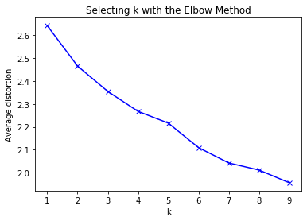

```python
#Finding optimal no. of clusters
from sklearn.cluster import KMeans

from scipy.stats import zscore
from scipy.spatial.distance import cdist
clusters=range(1,10)
meanDistortions=[]

for k in clusters:
    model=KMeans(n_clusters=k)
    model.fit(df1)
    prediction=model.predict(df1)
    meanDistortions.append(sum(np.min(cdist(df1, model.cluster_centers_, 'euclidean'), axis=1)) / df1.shape[0])


plt.plot(clusters, meanDistortions, 'bx-')
plt.xlabel('k')
plt.ylabel('Average distortion')
plt.title('Selecting k with the Elbow Method')
```

### Observation

Though the bend is not coming out clearly as there are many bends, let us look at 5 clusters

## K- Means with Clusters 5

```python
# Let us first start with K = 3
final_model=KMeans(5)
label=final_model.fit_predict(df1)


df["label"] = label
#df1["label"] = label
```

```python
df['label'].value_counts()
```

```
1    201
0     87
2     29
3     12
4      3
Name: label, dtype: int64
```

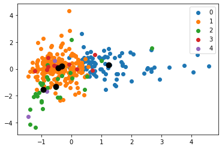

```python
#Getting unique labels
centroids = final_model.cluster_centers_
u_label = np.unique(label)

#plotting the results:

for i in u_label:
    plt.scatter(df1[label == i , 0] , df1[label == i , 1] , label = i)
plt.scatter(centroids[:,0] , centroids[:,1] , s = 80, color = 'k')
plt.legend()
plt.show()
```

## Hierarchical Clustering

```python
from sklearn.preprocessing import StandardScaler, normalize
from sklearn.decomposition import PCA
import scipy.cluster.hierarchy as hc
import matplotlib.pyplot as plt
from sklearn.cluster import AgglomerativeClustering
```

## PCA with Dendogram

Reducing the components to 5 features thru PCA

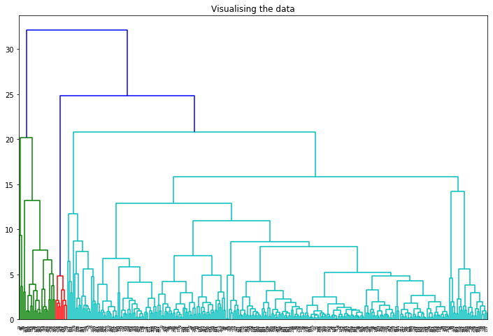

```python
pca = PCA(n_components=5)
df_pca = pca.fit_transform(df1)
df_pca = pd.DataFrame(df_pca)
df_pca.columns = ['P1', 'P2', 'P3','P4','P5']
#
# Create the Dendogram plot
#
plt.figure(figsize =(12, 8))
plt.title('Visualising the data')
dendrogram = hc.dendrogram((hc.linkage(df_pca, method ='ward')))
```

### Agglomerative hierarchical clustering

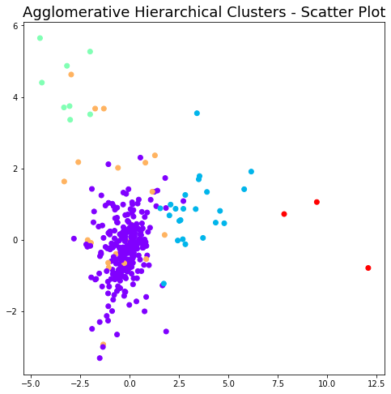

```python
agc = AgglomerativeClustering(n_clusters = 5)

label_hier = agc.fit_predict(df_pca)

plt.figure(figsize =(8, 8))
plt.scatter(df_pca['P1'], df_pca['P2'], c = agc.fit_predict(df_pca), cmap ='rainbow')
plt.title("Agglomerative Hierarchical Clusters - Scatter Plot", fontsize=18)
plt.show()
```

```python
df["label_hier"] = label_hier
```

## K-means vs Hierarchical Clustering

```python
df.groupby(['label','label_hier']).size()
```

```
label  label_hier
0      0              78
       3               9
1      0             195
       3               6
2      0               4
       1              23
       3               2
3      2               8
       3               4
4      4               3
dtype: int64
```

### K-Means Clustering Box Plot

```
array([[<matplotlib.axes._subplots.AxesSubplot object at 0x12fa8be10>,
      dtype=object)
```

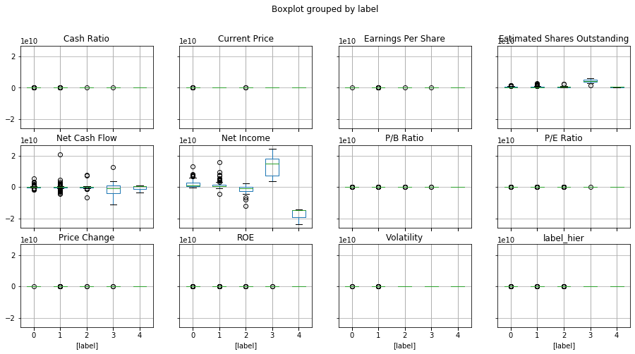

```python
df.boxplot(by='label', layout = (4,4),figsize=(15,10))
```

```
array([[<matplotlib.axes._subplots.AxesSubplot object at 0x130ada450>,
      dtype=object)
```

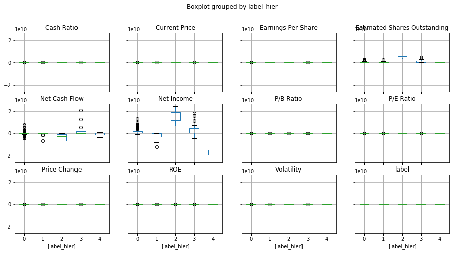

```python
df.boxplot(by='label_hier', layout = (4,4),figsize=(15,10))
```

### Obervations :

The Hierarchical clustering has more clear clustering than the K - Means\ Lable -2 in Hierarchical CLustering are high Net Income records\ Label-3 in k-Means are high Net Income records

## Actionable Insights and Recommendations

-

1) The clustering in bothe k-Means& Hierarchical is mainly based on the Net Income . \ 2) The second influceing feature for theclustering is Net Cash Flow